# FRIS/IWMS Analysis: No maps or trends plots

### Livestock

*Key Variables Code Chunk V)*: K982 changed from “What percent of total sales were from livestock sales?” in 2003 to “What percent of total sales were from non-irigated crop sales and/or livestock sales?” in 2008/2013/2018. Coded as a binary indicator in value-crop-sales.Rmd assuming that IF irrigators answered any percentage in K982, some part of their operation had livestock.

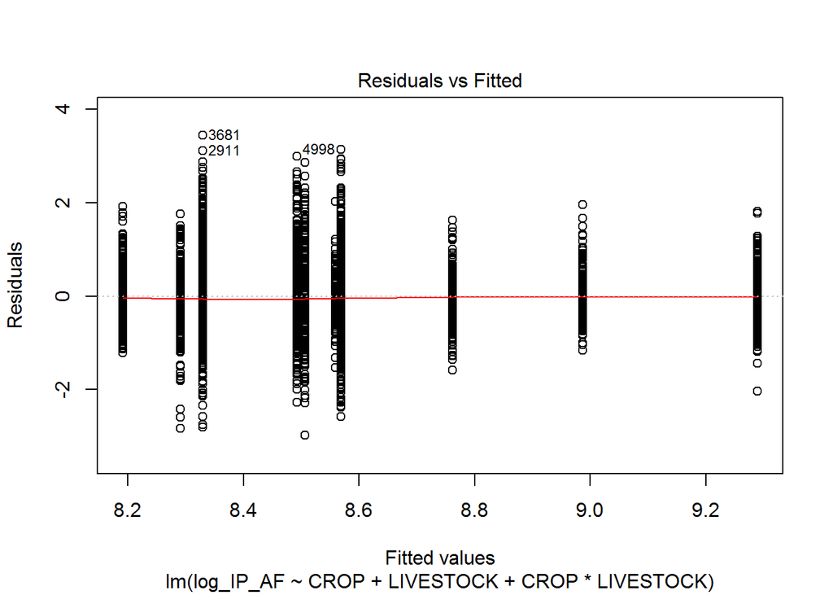

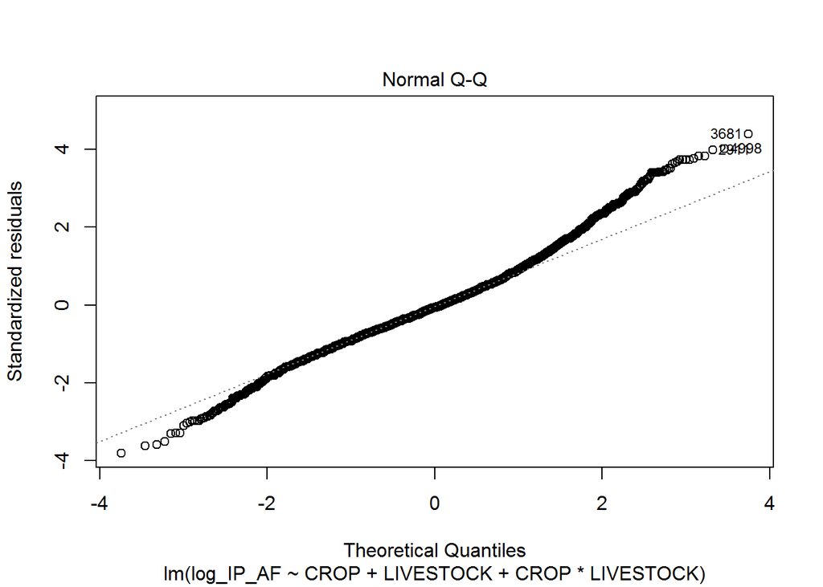

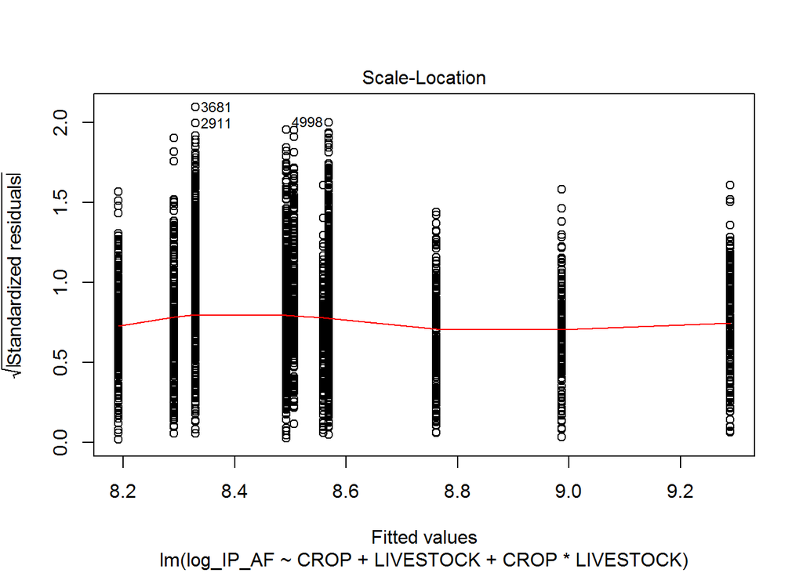

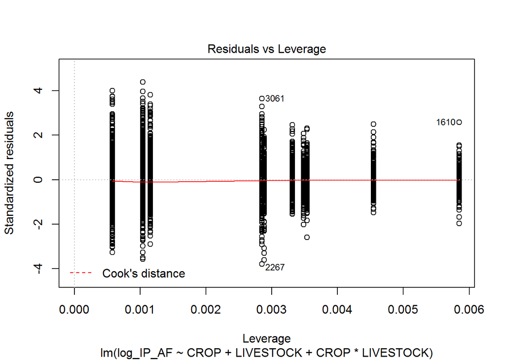

```r
# select only where LIVESTOCK is not NA
livestock <- anova_data %>% filter(!is.na(LIVESTOCK))
livestock$LIVESTOCK <- ifelse(livestock$LIVESTOCK == 1, "Yes", "No")

# LIVESTOCK
livestock_lm <- lm(log_IP_AF ~ CROP + LIVESTOCK + CROP*LIVESTOCK, data = livestock)
plot(livestock_lm)
```